# Sector Rotation In the Stock Market

Niyog

2025-11-04

**Introduction**

[output not shown]

[output not shown]

Even though I have included all 11 sectors, we’ll mostly focus on Technology, Financials, Energy, Consumer Discretionary, Healthcare, and Utilities since these sectors are the most influential in the market.

Firstly, I will load the data for all S&P 500 sector ETFs from Yahoo Finance and save it under a new variable. Each ticker (like XLK, XLF, or XLE) represents one major sector of the S&P 500 (indexed in the table above). We’ll collect daily price data from 2000–2025.

```r
# Reading sector ETF data from Yahoo Finance
# Using tidyquant to pull multiple tickers at once

etfs <- c("XLK","XLF","XLV","XLE","XLY","XLP","XLI","XLU","XLB","XLRE","XLC")

sector_data <- tq_get(etfs,
                      from = "2000-01-01",
                      to   = "2025-12-31") %>%
  group_by(symbol)

glimpse(sector_data)
```

```
## Rows: 63,143
## Columns: 8
## Groups: symbol [11]
## $ symbol   <chr> "XLK", "XLK", "XLK", "XLK", "XLK", "XLK", "XLK", "XLK", "XLK"…
## $ date     <date> 2000-01-03, 2000-01-04, 2000-01-05, 2000-01-06, 2000-01-07, …
## $ open     <dbl> 27.81250, 27.00000, 25.87500, 25.62500, 24.81250, 26.50000, 2…
## $ high     <dbl> 27.81250, 27.37500, 26.53125, 26.04688, 25.50000, 26.71875, 2…
## $ low      <dbl> 26.75000, 26.15625, 25.06250, 24.81250, 24.56250, 26.03125, 2…
## $ close    <dbl> 27.71875, 26.31250, 25.92188, 25.06250, 25.50000, 26.46875, 2…
## $ volume   <dbl> 1876200, 1091000, 3812000, 3340000, 1372000, 2041000, 2822600…
## $ adjusted <dbl> 20.68336, 19.63403, 19.34255, 18.70129, 19.02776, 19.75062, 1…
```

```r
unique(sector_data$symbol)
```

```
##  [1] "XLK"  "XLF"  "XLV"  "XLE"  "XLY"  "XLP"  "XLI"  "XLU"  "XLB"  "XLRE"
## [11] "XLC"
```

**Check for missing values** Let’s check if there are any missing values.

```r
#to check if there are any missing values in the dataset.
colSums(is.na(sector_data))
```

```
##   symbol     date     open     high      low    close   volume adjusted
##        0        0        0        0        0        0        0        0
```

So that means there are no missing data.

**Primary ETFs** Using all 11 ETFs would clutter the graphs and make it difficult to get insights. That’s why I’ll only use 6 ETFs that are the most influential.

```r
primary_etfs <- c("XLK", "XLF", "XLE", "XLY", "XLV", "XLU")
primary_data <- sector_data %>%
  filter(symbol %in% primary_etfs)
```

**Extracting Key Columns**

It’s not a good idea to keep all the variables as it doesn’t make our analysis efficient. That’s why I’ll only be using three variables. These should be enough to get what we want out of this dataset. The variables are:

Symbol – the ticker symbol of the ETF

Date – the date of the data

Adjusted – the closing price of that day for the ETF. “Adjusted” refers to the price that has accounted for actions like stock splits, dividends and so on.

```r
primary_data <- primary_data %>%
  select(symbol, date, adjusted)
glimpse(primary_data)
```

```
## Rows: 39,138
## Columns: 3
## Groups: symbol [6]
## $ symbol   <chr> "XLK", "XLK", "XLK", "XLK", "XLK", "XLK", "XLK", "XLK", "XLK"…
## $ date     <date> 2000-01-03, 2000-01-04, 2000-01-05, 2000-01-06, 2000-01-07, …
## $ adjusted <dbl> 20.68336, 19.63403, 19.34255, 18.70129, 19.02776, 19.75062, 1…
```

**Creating a “Year” Column**

I want to see how the ETFs have performed in and around major market movements. For that, we’ll need the yearly ETF data.

```r
library(lubridate)
primary_data <- primary_data %>%
  mutate(year = year(date))
glimpse(primary_data)
```

```
## Rows: 39,138
## Columns: 4
## Groups: symbol [6]
## $ symbol   <chr> "XLK", "XLK", "XLK", "XLK", "XLK", "XLK", "XLK", "XLK", "XLK"…
## $ date     <date> 2000-01-03, 2000-01-04, 2000-01-05, 2000-01-06, 2000-01-07, …
## $ adjusted <dbl> 20.68336, 19.63403, 19.34255, 18.70129, 19.02776, 19.75062, 1…
## $ year     <dbl> 2000, 2000, 2000, 2000, 2000, 2000, 2000, 2000, 2000, 2000, 2…
```

Now we can easily group data by year later.

**Calculating Daily Returns** This step generates two new columns daily_return and cumulative_return. daily_return refers to day-to-day change in the prices and cumulative_return refers to thetotal increase/decrease in the ETFs from the beginning of the time period. This helps us measure volatility patterns of the ETFs and see their nature in and around major crashes.

```r
primary_data <- primary_data %>%
  group_by(symbol) %>%
  arrange(date) %>%
  mutate(daily_return = (adjusted - lag(adjusted)) / lag(adjusted), #(Today-Yesterday)/Yesterday
         cumulative_return = (adjusted / first(adjusted)) - 1) #(Today/first day) - 1

glimpse(primary_data)
```

```
## Rows: 39,138
## Columns: 6
## Groups: symbol [6]
## $ symbol            <chr> "XLK", "XLF", "XLV", "XLE", "XLY", "XLU", "XLK", "XL…
## $ date              <date> 2000-01-03, 2000-01-03, 2000-01-03, 2000-01-03, 200…
## $ adjusted          <dbl> 20.683357, 11.186873, 20.612179, 6.756514, 11.195574…
## $ year              <dbl> 2000, 2000, 2000, 2000, 2000, 2000, 2000, 2000, 2000…
## $ daily_return      <dbl> NA, NA, NA, NA, NA, NA, -0.050732956, -0.043715554, …
## $ cumulative_return <dbl> 0.000000000, 0.000000000, 0.000000000, 0.000000000, …
```

This creates a new column **daily_return** and **cumulative_return** for each ETF.

**Removing NA values** Since the first trading day for each ETF has no previous price to compare against, its daily_return value is NA. These rows do not contribute to our analysis so we remove them to keep the dataset clean.

```r
primary_data <- primary_data %>%
  drop_na(daily_return)
glimpse(primary_data)
```

```
## Rows: 39,132
## Columns: 6
## Groups: symbol [6]
## $ symbol            <chr> "XLK", "XLF", "XLV", "XLE", "XLY", "XLU", "XLK", "XL…
## $ date              <date> 2000-01-04, 2000-01-04, 2000-01-04, 2000-01-04, 200…
## $ adjusted          <dbl> 19.634029, 10.697833, 20.144444, 6.629331, 10.858781…
## $ year              <dbl> 2000, 2000, 2000, 2000, 2000, 2000, 2000, 2000, 2000…
## $ daily_return      <dbl> -0.050732956, -0.043715554, -0.022692181, -0.0188238…
## $ cumulative_return <dbl> -0.050732956, -0.043715554, -0.022692181, -0.0188238…
```

Now we can confirm that all NA values have been removed leaving us with a clean set of valid daily returns for analysis.

**Let’s see if each ETF has data for multiple years**

```r
primary_data %>%
  group_by(symbol) %>%
  summarise(start = min(date), end = max(date))
```

```
## # A tibble: 6 × 3
##   symbol start      end
##   <chr>  <date>     <date>
## 1 XLE    2000-01-04 2025-12-08
## 2 XLF    2000-01-04 2025-12-08
## 3 XLK    2000-01-04 2025-12-08
## 4 XLU    2000-01-04 2025-12-08
## 5 XLV    2000-01-04 2025-12-08
## 6 XLY    2000-01-04 2025-12-08
```

```r
glimpse(primary_data)
```

```
## Rows: 39,132
## Columns: 6
## Groups: symbol [6]
## $ symbol            <chr> "XLK", "XLF", "XLV", "XLE", "XLY", "XLU", "XLK", "XL…
## $ date              <date> 2000-01-04, 2000-01-04, 2000-01-04, 2000-01-04, 200…
## $ adjusted          <dbl> 19.634029, 10.697833, 20.144444, 6.629331, 10.858781…
## $ year              <dbl> 2000, 2000, 2000, 2000, 2000, 2000, 2000, 2000, 2000…
## $ daily_return      <dbl> -0.050732956, -0.043715554, -0.022692181, -0.0188238…
## $ cumulative_return <dbl> -0.050732956, -0.043715554, -0.022692181, -0.0188238…
```

**Now everything looks good and the data’s all set. Time to start asking some questions.**

**1. How have different sectors performed over time?**

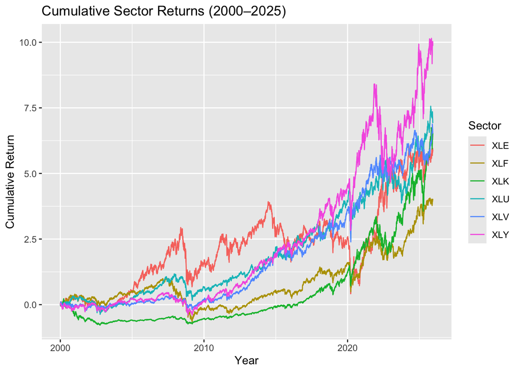

```r
sector_trend <- primary_data %>%
  group_by(symbol) %>%
  arrange(date) %>%
  mutate(cumulative_return = (adjusted / first(adjusted)) - 1)

ggplot(sector_trend, aes(x=date, y=cumulative_return, color=symbol)) +
  geom_line() +
  labs(title="Cumulative Sector Returns (2000–2025)",
       y="Cumulative Return",
       x="Year",
       color="Sector")
```

**2. Which sectors performed best and worst on a daily basis ?**

```r
#Calculating average daily return
yearly_avg <- primary_data %>%
  group_by(symbol, year) %>%
  summarise(avg_return = mean(daily_return, na.rm = TRUE))
```

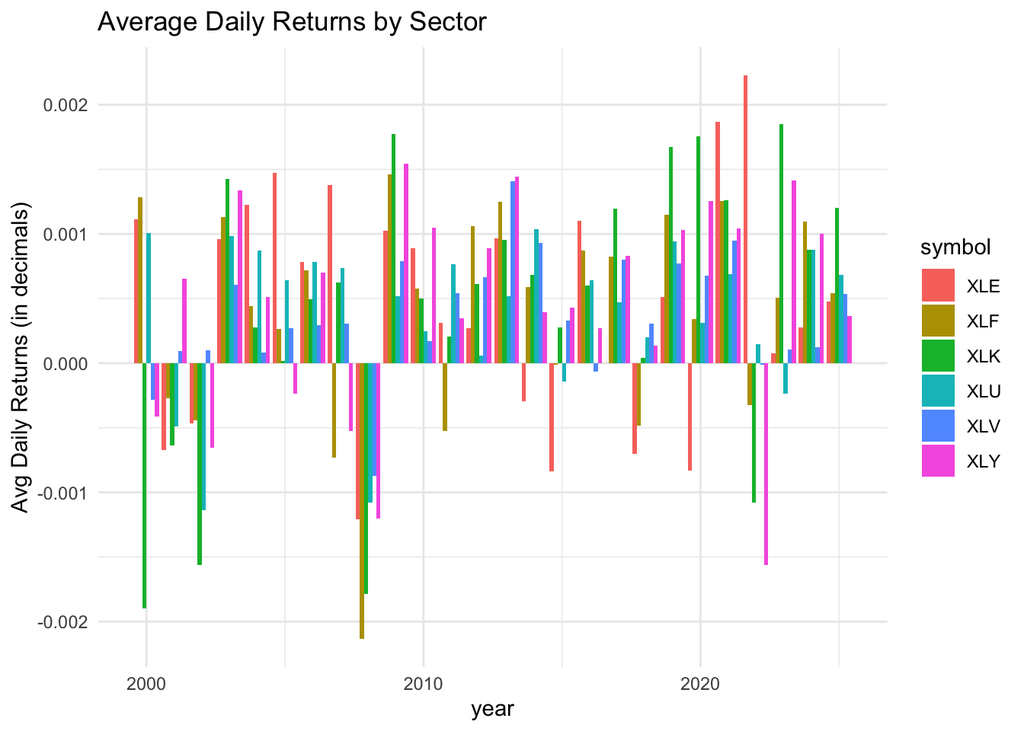

```r
ggplot(yearly_avg, aes(x = year, y = avg_return, fill = symbol)) +
  geom_col(position="dodge") +
  labs(title="Average Daily Returns by Sector", y="Avg Daily Returns (in decimals)") +
  theme_minimal()
```

**3. How did sectors behave around major market events?** Major market events often reveal how different sectors respond to stress and recovery. Here, we examine sector trends around crises like the 2008 recession and the 2020 pandemic.

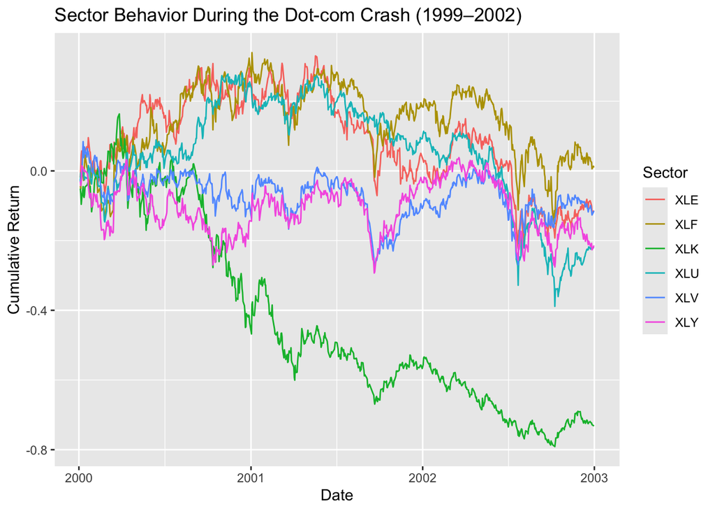

```r
dotcom <- filter(primary_data, year >= 1999 & year <= 2002)
crash2008 <- filter(primary_data, year >= 2007 & year <= 2009)
covid <- filter(primary_data, year >= 2019 & year <= 2021)

#dotcom crash
ggplot(dotcom, aes(x=date, y=cumulative_return, color=symbol)) +
  geom_line() +
  labs(title="Sector Behavior During the Dot-com Crash (1999–2002)",
       x="Date", y="Cumulative Return", color="Sector")
```

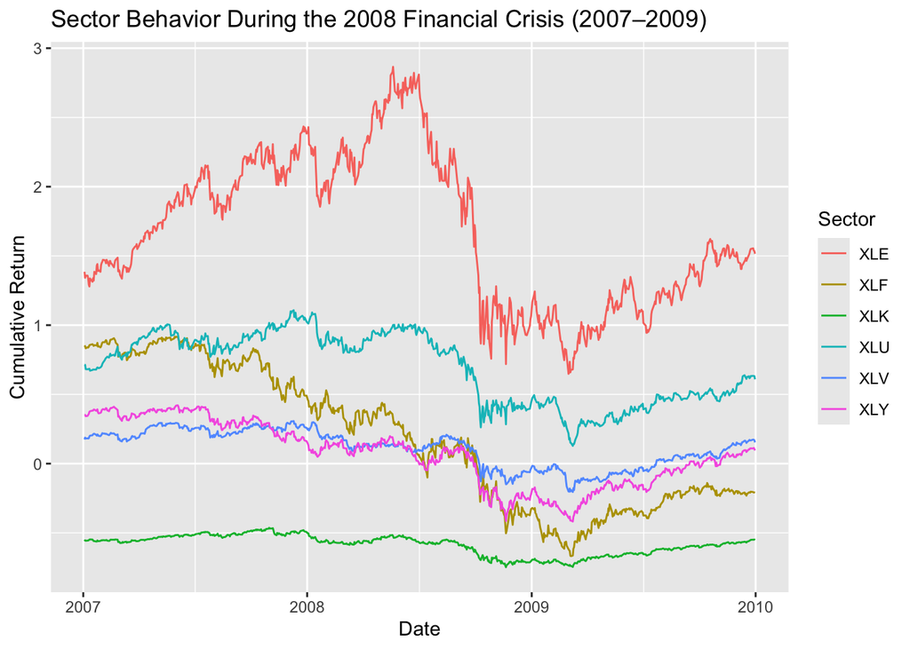

```r
#financial crisis of 2008
ggplot(crash2008, aes(x=date, y=cumulative_return, color=symbol)) +
  geom_line() +
  labs(title="Sector Behavior During the 2008 Financial Crisis (2007–2009)",
       x="Date", y="Cumulative Return", color="Sector")
```

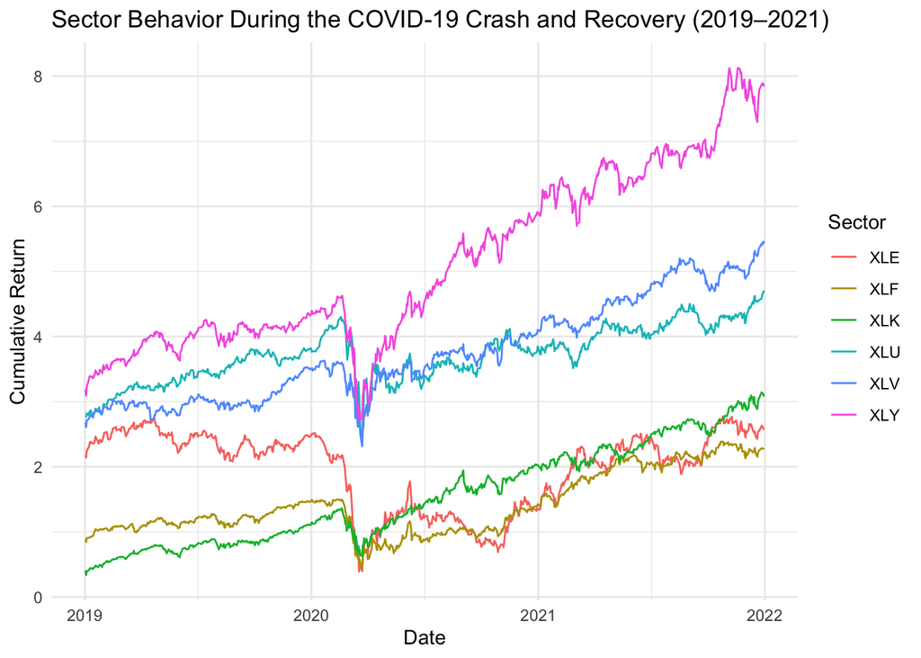

```r
#Pandemic
ggplot(covid, aes(x=date, y=cumulative_return, color=symbol)) +
  geom_line() +
  labs(title="Sector Behavior During the COVID-19 Crash and Recovery (2019–2021)",
       x="Date", y="Cumulative Return", color="Sector") +
  theme_minimal()
```

Dot-com Crash During the dot-com crash, the Technology sector (XLK) suffered the sharpest decline as the bubble burst. This erased massive gains from the late 1990s. Most of the others remained fairly stable, with Financials being the safest. This shows that the Dot-com crash, as its name suggests, was driven by extreme hype around tech back then(We can see similar sentiment nowadays with AI but that’s outside the scope of this project.)

2008 Financial Crisis The 2008 crisis caused sharp declines across nearly all sectors with Financials (XLF) among the hardest hit due to the banking collapse. Energy (XLE) initially outperformed but later dropped as demand weakened.

**4. Are some sectors more volatile than others?** As we’ve seen in the previous graphs, different sectors move differently over time. In this graph we compare their volatility.

```r
#SD of daily returns
volatility <- primary_data %>%
  group_by(symbol, year) %>%
  summarise(sd_return = sd(daily_return, na.rm = TRUE))
```

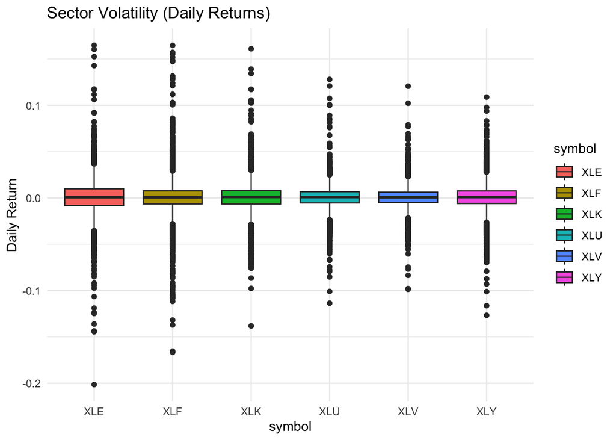

```r
#Boxplot
ggplot(primary_data, aes(x=symbol, y=daily_return, fill=symbol)) +
  geom_boxplot() +
  labs(title="Sector Volatility (Daily Returns)", y="Daily Return") +
  theme_minimal()
```

**Average Daily return By Sector**

```r
avg_returns <- primary_data %>%
  group_by(symbol) %>%
  summarise(mean_daily_return = mean(daily_return, na.rm = TRUE)) #average in decimals

avg_returns
```

```
## # A tibble: 6 × 2
##   symbol mean_daily_return
##   <chr>              <dbl>
## 1 XLE             0.000458
## 2 XLF             0.000401
## 3 XLK             0.000434
## 4 XLU             0.000387
## 5 XLV             0.000369
## 6 XLY             0.000464
```

These numbers represent average daily returns of the ETFs. Higher value means the sector grew slightly more per day over the time period. From the results, Consumer Discretionary and Energy have the highest average daily returns, meaning they generally showed the strongest daily performance among the sectors I analyzed. Healthcare and Utilities have the lowest averages, which makes sense because these sectors are usually more stable and defensive. Financials and Technology sit in the middle which shows a mix of higher growth but also periods of large drawdowns during major market events.